# Презентация по 4-ому этапу индивидуального проекта

Дисциплина: Архитектура компьютеров и операционные системы

Гусев Степан Андреевич

1032242444@rudn.ru

Российский университет дружбы народов

2026-04-28

# Информация

**Презентация по 4-ому этапу индивидуального проекта**

**Автор:** Гусев Степан Андреевич

**Преподаватель:** Кулябов Дмитрий Сергеевич, д.ф.-м.н., профессор кафедры теории вероятностей и кибербезопасности

Российский университет дружбы народов

## Докладчик

- Гусев Степан Андреевич
- Студент программы “Бизнес-информатика”
- Российский университет дружбы народов им. П. Лумумбы
- 1032242444@rudn.ru
- https://github.com/stepagusev

## Цель

Продолжить работу над 4-ым этапом индивидуального проекта, добавить к сайту ссылки на профили.

## Задание

1. Зарегистрироваться на ресурсах и разместить на них ссылки.
2. Создать пост по прошедшей неделе.
3. Создать пост на тему по выбору.

# Выполнение этапа индивидуального проекта

## Добавление ссылок

Перещёл в content/authors/me.

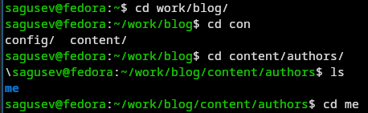

Рисунок 1: Перемещение в директорию

## Добавление ссылок

Открыл _index.md.

## Добавление ссылок

Добавил ссылки.

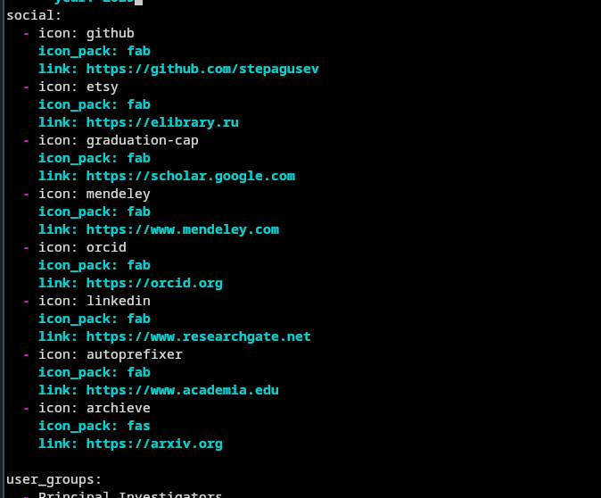

Рисунок 3: Изменение файла

## Создание поста по прошедшей неделе

В каталоге content/blog скопировал 2st-week в 3st-week, открыл index.md в 3st-week (рис. 4).

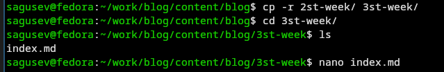

Рисунок 4: Копирование директории

## Создание поста по прошедшей неделе

В index.md вписал информацию о посте и сам пост (рис. 5).

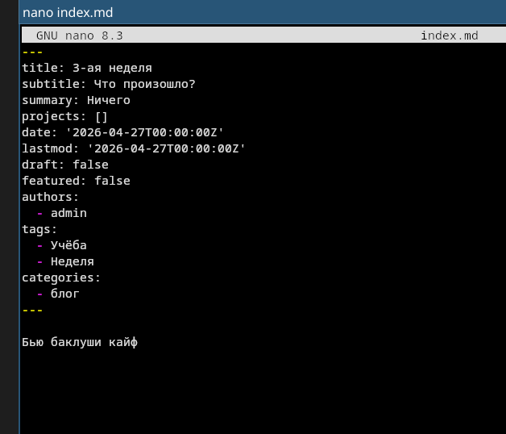

Рисунок 5: Изменение файла

## Создание поста по оформлению отчётов

В каталоге content/blog скопировал markup-languages в report-making, открыл index.md в report-making (рис. 6).

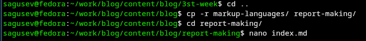

Рисунок 6: Копирование директории

## Создание поста по оформлению отчётов

В index.md вписал информацию о посте и сам пост (рис. 7).

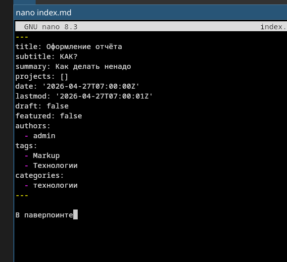

Рисунок 7: Изменение файла

# Выводы

## Выводы

Добавил на сайт ссылки на сайты, создал 2 поста, тем самым выполнив 4-ый этап индивидуального проекта.